# Chapter 8: Exploratory Factor Analysis

Statistical Modelling Methods: A Guide for the Social and Behavioural Sciences (2nd ed.)

Author

David Flora & Miranda Too

# Chapter 8 Textbook Content

## Loading R Packages

```r
library(EFA.dimensions)
library(psych)
library(stats)
library(misty)
```

## Importing data

```r
saasdat <- read.table("saasdat.dat", header=T)
```

## Research Example

*N* = 109 university students completed the SAAS in addition to the Brief Fear of Negative Evaluation Scale (BFNE), the Social Interaction Anxiety Scale (SIAS), the Social Phobia Scale (SPS), the Social Physique Anxiety Scale (SPAS), the Body-Image Ideals Questionnaire (BIQ), the Appearance Schemas Inventory (ASI), and finally the Appearance Evaluation (APEVAL) and Overweight-Preoccupation (OWPRE) subscales from the Multidimensional Body-Self Relations Questionnaire (see Hart et al. for references and descriptions of each of these tests).

### Table 8.1: Bivariate Correlations

```r
cor(saasdat, use = "complete.obs")
```

```
             BFNE       SIAS        SPS       SPAS        BIQ        ASI
BFNE    1.0000000  0.7104779  0.6735280  0.6130940  0.6396733  0.5332789
SIAS    0.7104779  1.0000000  0.8031380  0.4601799  0.4847555  0.3251174
SPS     0.6735280  0.8031380  1.0000000  0.4551282  0.4143057  0.4552828
SPAS    0.6130940  0.4601799  0.4551282  1.0000000  0.6281804  0.4949886
BIQ     0.6396733  0.4847555  0.4143057  0.6281804  1.0000000  0.5927788
ASI     0.5332789  0.3251174  0.4552828  0.4949886  0.5927788  1.0000000
APEVAL -0.5080165 -0.4499968 -0.4002273 -0.7786120 -0.5299369 -0.3422407
OWPRE   0.3901991  0.3048149  0.3716077  0.5934002  0.4698797  0.4304520
SAAS    0.8147172  0.7596721  0.7725470  0.5885544  0.5763725  0.4777224
           APEVAL      OWPRE       SAAS
BFNE   -0.5080165  0.3901991  0.8147172
SIAS   -0.4499968  0.3048149  0.7596721
SPS    -0.4002273  0.3716077  0.7725470
SPAS   -0.7786120  0.5934002  0.5885544
BIQ    -0.5299369  0.4698797  0.5763725
ASI    -0.3422407  0.4304520  0.4777224
APEVAL  1.0000000 -0.4322959 -0.5539804
OWPRE  -0.4322959  1.0000000  0.3671905
SAAS   -0.5539804  0.3671905  1.0000000
```

### Table 8.2: Factor Loading Matrix for Two Factor Model

EFA models can be estimated using the `fa()` function from the `psych` package. To apply this function, the variables for the analysis must be saved in their own data object, without any extra variables. The number of factors can be specified with the `nfactors =` argument. The estimated model can be saved into a model object, and results can be viewed using the `print()` function.

By default, `fa()` implements unweighted least squares estimation (referred to as “minres”, which stands for “minimized residuals”). Also, `fa()` implements oblimin rotation (with weight = 0) by default.

```r
#Specifying a two factor model
twoFmod <- fa(saasdat, nfactors=2)

#Printing the model fit statistics, factor loadings, communality, and uniqueness values:
print(twoFmod)
```

```
Factor Analysis using method =  minres
Call: fa(r = saasdat, nfactors = 2)
Standardized loadings (pattern matrix) based upon correlation matrix
         MR1   MR2   h2   u2 com
BFNE    0.66  0.28 0.74 0.26 1.3
SIAS    0.93 -0.08 0.77 0.23 1.0
SPS     0.91 -0.07 0.75 0.25 1.0
SPAS   -0.06  0.97 0.87 0.13 1.0
BIQ     0.18  0.63 0.58 0.42 1.2
ASI     0.19  0.48 0.38 0.62 1.3
APEVAL -0.07 -0.69 0.55 0.45 1.0
OWPRE  -0.01  0.63 0.39 0.61 1.0
SAAS    0.80  0.15 0.83 0.17 1.1

                       MR1  MR2
SS loadings           3.08 2.78
Proportion Var        0.34 0.31
Cumulative Var        0.34 0.65
Proportion Explained  0.53 0.47
Cumulative Proportion 0.53 1.00

 With factor correlations of
     MR1  MR2
MR1 1.00 0.63
MR2 0.63 1.00

Mean item complexity =  1.1
Test of the hypothesis that 2 factors are sufficient.

df null model =  36  with the objective function =  6.59 with Chi Square =  686.39
df of  the model are 19  and the objective function was  0.61

The root mean square of the residuals (RMSR) is  0.05
The df corrected root mean square of the residuals is  0.06

The harmonic n.obs is  109 with the empirical chi square  8.72  with prob <  0.98
The total n.obs was  109  with Likelihood Chi Square =  62.46  with prob <  1.6e-06

Tucker Lewis Index of factoring reliability =  0.872
RMSEA index =  0.145  and the 90 % confidence intervals are  0.106 0.186
BIC =  -26.68
Fit based upon off diagonal values = 0.99
Measures of factor score adequacy
                                                   MR1  MR2
Correlation of (regression) scores with factors   0.91 0.92
Multiple R square of scores with factors          0.82 0.84
Minimum correlation of possible factor scores     0.65 0.68
```

```r
#In the output under "Standardized loadings", the columns labeled MR1 and MR2 provide the factor loading estimates for the first and second factors, respectively ("MR" stands for "minres", which is the estimation method).
#The column labeled "h2" provides the communality estimates, while "u2" provides the uniquenesses.
# Note that "com" does NOT stand for communality; rather the "com" column provides a statistic called "factor complexity", which is not described in the text.
#The correlation between MR1 and MR2 is the inter-factor correlation, = .63 here.
```

## Determining the Optimal Number of Factors

### Figure 8.1: Scree Plot

The following code will create a scree plot identical to Figure 8.1 in the text:

```r
#Correlation matrix object
R <- cor(saasdat, use = "complete.obs")
#Creating eigenvalues object
D <- (eigen(R)$values)
#View eigenvalues
D
```

```
[1] 5.3191610 1.1618968 0.7541227 0.5935680 0.3960464 0.2826881 0.1907431
[8] 0.1704977 0.1312761
```

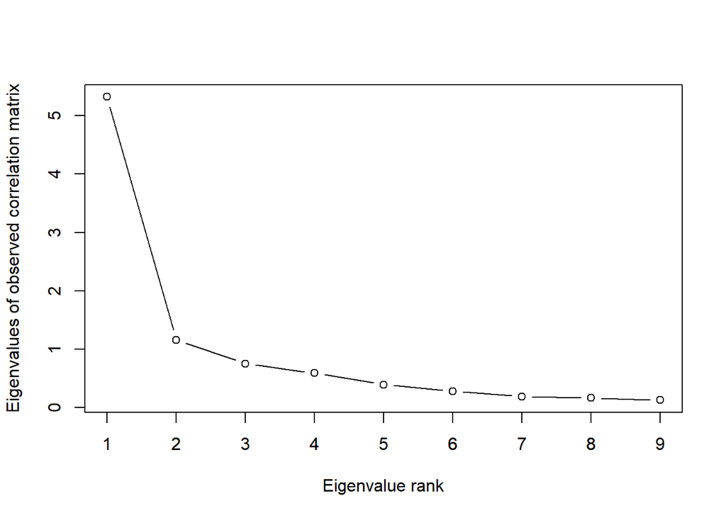

```r
#Creating the Scree plot
plot(D, type='b', ylab='Eigenvalues of observed correlation matrix', xlab='Eigenvalue rank')
axis(side=1, at=c(1:9))
```

Alternatively, the `SCREE_PLOT()` function of the `EFA.dimensions` package can be used to make a scree plot.

```
Cases with missing values were found and removed from the data matrix.
```

```
There were 1 cases with missing values, and 1 missing values in total.
```

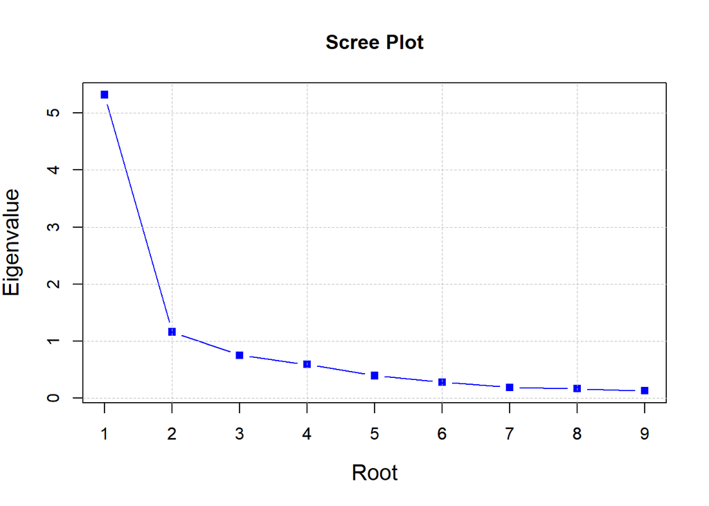

```
Scree Plot:
```

```
Specified kind of correlations for this analysis: Pearson
```

```
Total Variance Explained (Initial Eigenvalues):
```

```
            Eigenvalues    Proportion of Variance    Cumulative Prop. Variance
Factor 1           5.32                      0.59                         0.59
Factor 2           1.16                      0.13                         0.72
Factor 3           0.75                      0.08                         0.80
Factor 4           0.59                      0.07                         0.87
Factor 5           0.40                      0.04                         0.91
Factor 6           0.28                      0.03                         0.95
Factor 7           0.19                      0.02                         0.97
Factor 8           0.17                      0.02                         0.99
Factor 9           0.13                      0.01                         1.00
```

```r
SCREE_PLOT(saasdat)
```

Parallel analysis is another method of determining the optimal number of factors. The `RAWPAR()` function in the `EFA.dimensions` package runs a parallel analysis and creates a plot of the results which is the same as the scree plot, but also includes the 95th percentile eigenvalues generated from the random data for the parallel analysis. Regardless of the appearance of the plot, look to the final message in the output: “The number of factors according to the parallel analysis =”

```
Cases with missing values were found and removed from the data matrix.
```

```
There were 1 cases with missing values, and 1 missing values in total.
```

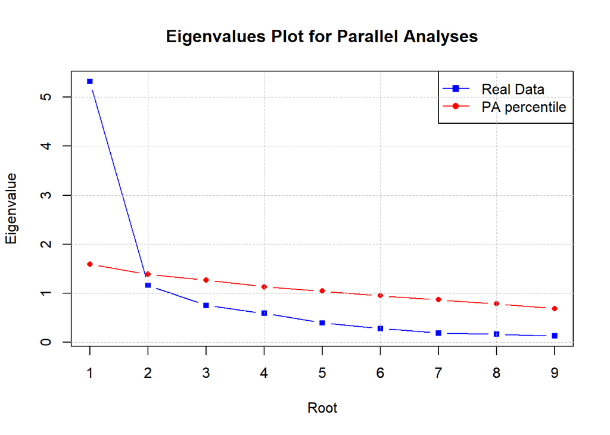

```
PARALLEL ANALYSIS
```

```
Randomization method: generated data
```

```
Type of correlations specified for the real data eigenvalues: Pearson
```

```
Type of correlations specified for the random data eigenvalues: pearson
```

```
Extraction Method: Principal Components
```

```
Variables = 9
```

```
Cases = 108
```

```
Ndatasets = 100
```

```
Percentile = 95
```

```
Compare the Real Data eigenvalues below to the corresponding
```

```
random data Mean and Percentile eigenvalues
```

```
   Root   Real_Data    Mean   Percentile
      1       5.319   1.445        1.591
      2       1.162   1.299        1.390
      3       0.754   1.178        1.268
      4       0.594   1.072        1.134
      5       0.396   0.990        1.046
      6       0.283   0.898        0.953
      7       0.191   0.805        0.870
      8       0.170   0.704        0.784
      9       0.131   0.609        0.691
```

```
The number of factors according to the parallel analysis = 1
```

```r
#Parallel Analysis
RAWPAR(saasdat)
```

```r
#The output says "Extraction method: Principal Components" despite that we are doing factor analysis.
#Principal components extraction in parallel analysis corresponds to the "traditional" parallel analysis method described in the text, and means that the parallel analysis is based on eigenvalues of the raw, "unreduced" correlation matrix, which is what we want.
#This issue is also discussed in the Help documentation; see ?RAWPAR
```

## Model Fit Statistics

```r
#Fitting one-, three-, and four-factor models for comparison.
#Note that the two-factor model was already estimated above.

#One Factor Model
oneFmod <- fa(saasdat, nfactors=1)
#Three Factor Model
threeFmod <- fa(saasdat, nfactors=3)
#Four Factor Model
fourFmod <- fa(saasdat, nfactors=4)
#Note that the four factor model has an improper solution.
```

### Root Mean Square Residual

```r
oneFmod$rms
```

```
[1] 0.1013853
```

```r
twoFmod$rms
```

```
[1] 0.04719365
```

```r
threeFmod$rms
```

```
[1] 0.02460024
```

```r
fourFmod$rms
```

```
[1] 0.01093558
```

### Root Mean Square Error of Approximation

```r
oneFmod$RMSEA
```

```
     RMSEA      lower      upper confidence
 0.2195890  0.1895832  0.2532497  0.9000000
```

```r
twoFmod$RMSEA
```

```
     RMSEA      lower      upper confidence
 0.1445620  0.1063678  0.1864037  0.9000000
```

```r
threeFmod$RMSEA
```

```
     RMSEA      lower      upper confidence
0.11926020 0.06830254 0.17357201 0.90000000
```

```r
fourFmod$RMSEA
```

```
     RMSEA      lower      upper confidence
 0.0516387  0.0000000  0.1430944  0.9000000
```

## Factor Rotation

The default factor rotation for the `fa()` function is oblimin (with weight = 0).

### Table 8.3: Two-Factor model with biquartimin rotation

For biquartimin rotation, change the oblimin weight to .5 using the `gam = .5` argument:

```r
twoFmodbr <- fa(saasdat, nfactors=2, gam =.5)
print(twoFmodbr)
```

```
Factor Analysis using method =  minres
Call: fa(r = saasdat, nfactors = 2, gam = 0.5)
Standardized loadings (pattern matrix) based upon correlation matrix
         MR1   MR2   h2   u2 com
BFNE    0.68  0.22 0.74 0.26 1.2
SIAS    1.05 -0.24 0.77 0.23 1.1
SPS     1.03 -0.22 0.75 0.25 1.1
SPAS   -0.26  1.13 0.87 0.13 1.1
BIQ     0.07  0.70 0.58 0.42 1.0
ASI     0.12  0.52 0.38 0.62 1.1
APEVAL  0.07 -0.79 0.55 0.45 1.0
OWPRE  -0.14  0.73 0.39 0.61 1.1
SAAS    0.87  0.05 0.83 0.17 1.0

                       MR1  MR2
SS loadings           3.01 2.84
Proportion Var        0.33 0.32
Cumulative Var        0.33 0.65
Proportion Explained  0.51 0.49
Cumulative Proportion 0.51 1.00

 With factor correlations of
     MR1  MR2
MR1 1.00 0.79
MR2 0.79 1.00

Mean item complexity =  1.1
Test of the hypothesis that 2 factors are sufficient.

df null model =  36  with the objective function =  6.59 with Chi Square =  686.39
df of  the model are 19  and the objective function was  0.61

The root mean square of the residuals (RMSR) is  0.05
The df corrected root mean square of the residuals is  0.06

The harmonic n.obs is  109 with the empirical chi square  8.72  with prob <  0.98
The total n.obs was  109  with Likelihood Chi Square =  62.46  with prob <  1.6e-06

Tucker Lewis Index of factoring reliability =  0.872
RMSEA index =  0.145  and the 90 % confidence intervals are  0.106 0.186
BIC =  -26.68
Fit based upon off diagonal values = 0.99
Measures of factor score adequacy
                                                  MR1 MR2
Correlation of (regression) scores with factors     1   1
Multiple R square of scores with factors            1   1
Minimum correlation of possible factor scores       1   1
```

```r
#The factor loading estimates don't exactly match those in Table 8.3.
#This discrepancy is likely due to R package updates which changed the technical implementations of the rotation methods.
#But it is also possible that Table 8.3 contains typographical errors!
```

### Table 8.4: One-Factor Model

```r
#Factor loadings and communalities
print(oneFmod)
```

```
Factor Analysis using method =  minres
Call: fa(r = saasdat, nfactors = 1)
Standardized loadings (pattern matrix) based upon correlation matrix
         MR1   h2   u2 com
BFNE    0.86 0.74 0.26   1
SIAS    0.75 0.57 0.43   1
SPS     0.75 0.57 0.43   1
SPAS    0.78 0.60 0.40   1
BIQ     0.73 0.53 0.47   1
ASI     0.61 0.37 0.63   1
APEVAL -0.67 0.46 0.54   1
OWPRE   0.55 0.30 0.70   1
SAAS    0.87 0.76 0.24   1

                MR1
SS loadings    4.90
Proportion Var 0.54

Mean item complexity =  1
Test of the hypothesis that 1 factor is sufficient.

df null model =  36  with the objective function =  6.59 with Chi Square =  686.39
df of  the model are 27  and the objective function was  1.63

The root mean square of the residuals (RMSR) is  0.1
The df corrected root mean square of the residuals is  0.12

The harmonic n.obs is  109 with the empirical chi square  40.26  with prob <  0.048
The total n.obs was  109  with Likelihood Chi Square =  169.16  with prob <  1.6e-22

Tucker Lewis Index of factoring reliability =  0.707
RMSEA index =  0.22  and the 90 % confidence intervals are  0.19 0.253
BIC =  42.49
Fit based upon off diagonal values = 0.97
Measures of factor score adequacy
                                                   MR1
Correlation of (regression) scores with factors   0.96
Multiple R square of scores with factors          0.93
Minimum correlation of possible factor scores     0.86
```

Residual correlations for one-factor and two-factor models:

```r
round(oneFmod$residual, 2)
```

```
        BFNE  SIAS   SPS  SPAS   BIQ   ASI APEVAL OWPRE  SAAS
BFNE    0.26  0.06  0.03 -0.06  0.01  0.01   0.07 -0.08  0.07
SIAS    0.06  0.43  0.23 -0.13 -0.07 -0.13   0.06 -0.10  0.11
SPS     0.03  0.23  0.43 -0.13 -0.14  0.00   0.11 -0.05  0.12
SPAS   -0.06 -0.13 -0.13  0.40  0.06  0.02  -0.25  0.16 -0.09
BIQ     0.01 -0.07 -0.14  0.06  0.47  0.15  -0.04  0.06 -0.06
ASI     0.01 -0.13  0.00  0.02  0.15  0.63   0.07  0.10 -0.05
APEVAL  0.07  0.06  0.11 -0.25 -0.04  0.07   0.54 -0.06  0.03
OWPRE  -0.08 -0.10 -0.05  0.16  0.06  0.10  -0.06  0.70 -0.11
SAAS    0.07  0.11  0.12 -0.09 -0.06 -0.05   0.03 -0.11  0.24
```

```r
#one-factor model residual correlations are above
#note that the diagonal elements equal the uniqueness estimates of each observed variable

round(twoFmod$residual, 2)
```

```
        BFNE  SIAS   SPS  SPAS   BIQ   ASI APEVAL OWPRE  SAAS
BFNE    0.26 -0.01 -0.04 -0.01  0.05  0.04   0.03 -0.04  0.04
SIAS   -0.01  0.23  0.04  0.02  0.01 -0.08  -0.04  0.00 -0.02
SPS    -0.04  0.04  0.25  0.01 -0.06  0.04   0.01  0.05  0.00
SPAS   -0.01  0.02  0.01  0.13 -0.06 -0.06  -0.09  0.01  0.00
BIQ     0.05  0.01 -0.06 -0.06  0.42  0.12   0.03  0.00 -0.01
ASI     0.04 -0.08  0.04 -0.06  0.12  0.62   0.11  0.06 -0.01
APEVAL  0.03 -0.04  0.01 -0.09  0.03  0.11   0.45  0.03 -0.03
OWPRE  -0.04  0.00  0.05  0.01  0.00  0.06   0.03  0.61 -0.04
SAAS    0.04 -0.02  0.00  0.00 -0.01 -0.01  -0.03 -0.04  0.17
```

```r
#two-factor model residual correlations are above
#note that the diagonal elements equal the uniqueness estimates of each observed variable
```

### Table 8.5: Three-Factor Model

```r
threeFmod <- fa(saasdat, nfactors=3)
print(threeFmod)
```

```
Factor Analysis using method =  minres
Call: fa(r = saasdat, nfactors = 3)
Standardized loadings (pattern matrix) based upon correlation matrix
         MR1   MR2   MR3   h2   u2 com
BFNE    0.64  0.14  0.21 0.74 0.26 1.3
SIAS    0.96 -0.01 -0.12 0.82 0.18 1.0
SPS     0.87 -0.09  0.07 0.74 0.26 1.0
SPAS   -0.03  0.97  0.04 0.95 0.05 1.0
BIQ     0.15  0.36  0.40 0.59 0.41 2.3
ASI     0.04  0.00  0.85 0.76 0.24 1.0
APEVAL -0.10 -0.80  0.11 0.66 0.34 1.1
OWPRE   0.00  0.44  0.25 0.38 0.62 1.6
SAAS    0.79  0.12  0.07 0.82 0.18 1.1

                       MR1  MR2  MR3
SS loadings           2.99 2.20 1.27
Proportion Var        0.33 0.24 0.14
Cumulative Var        0.33 0.58 0.72
Proportion Explained  0.46 0.34 0.20
Cumulative Proportion 0.46 0.80 1.00

 With factor correlations of
     MR1  MR2  MR3
MR1 1.00 0.59 0.50
MR2 0.59 1.00 0.54
MR3 0.50 0.54 1.00

Mean item complexity =  1.3
Test of the hypothesis that 3 factors are sufficient.

df null model =  36  with the objective function =  6.59 with Chi Square =  686.39
df of  the model are 12  and the objective function was  0.3

The root mean square of the residuals (RMSR) is  0.02
The df corrected root mean square of the residuals is  0.04

The harmonic n.obs is  109 with the empirical chi square  2.37  with prob <  1
The total n.obs was  109  with Likelihood Chi Square =  30.71  with prob <  0.0022

Tucker Lewis Index of factoring reliability =  0.912
RMSEA index =  0.119  and the 90 % confidence intervals are  0.068 0.174
BIC =  -25.58
Fit based upon off diagonal values = 1
Measures of factor score adequacy
                                                   MR1  MR2  MR3
Correlation of (regression) scores with factors   0.93 0.90 0.79
Multiple R square of scores with factors          0.86 0.80 0.62
Minimum correlation of possible factor scores     0.72 0.61 0.25
```

## EFA with Categorical Observed Variables

Nissim et al. (2010) administered the Beck Hopelessness Scale (BHS) to patients with advanced cancer. The dataset includes N = 170 patients’ responses to the 20-item BHS.

```r
bhsdat <- read.csv("bhsefa.csv", header = F)
```

### Polychoric correlations

Polychoric correlations can be obtained with the `method = "poly"` argument of the `cor.matrix()` function from the `misty` package:

```r
cor.matrix(bhsdat, method = "poly")
```

```
 Polychoric Correlation Coefficient

         V1    V2   V3   V4   V5   V6   V7    V8   V9   V10  V11  V12  V13  V14  V15  V16  V17  V18  V19 V20
  V1
  V2   0.49
  V3   0.71  0.41
  V4   0.50  0.73 0.61
  V5   0.63  0.40 0.83 0.77
  V6   0.57  0.54 0.56 0.74 0.68
  V7   0.65  0.46 0.66 0.84 0.84 0.74
  V8  -0.13  0.48 0.19 0.51 0.40 0.56 0.33
  V9   0.47  0.42 0.67 0.79 0.84 0.80 0.75  0.50
  V10  0.59  0.57 0.68 0.62 0.68 0.69 0.57  0.56 0.58
  V11  0.40  0.76 0.48 0.81 0.58 0.70 0.63  0.56 0.80  0.46
  V12  0.43  0.17 0.75 0.58 0.76 0.67 0.57  0.32 0.68  0.62 0.34
  V13  0.36 -0.09 0.44 0.33 0.36 0.20 0.31 -0.41 0.32 -0.02 0.10 0.59
  V14  0.62  0.31 0.56 0.34 0.57 0.60 0.42  0.17 0.34  0.50 0.20 0.62 0.31
  V15  0.44  0.12 0.65 0.52 0.71 0.72 0.62  0.31 0.63  0.57 0.32 0.82 0.49 0.70
  V16  0.20  0.24 0.51 0.56 0.67 0.57 0.56  0.60 0.62  0.41 0.53 0.66 0.19 0.39 0.48
  V17  0.28  0.19 0.46 0.46 0.53 0.52 0.48  0.36 0.54  0.44 0.45 0.46 0.24 0.41 0.46 0.49
  V18  0.66  0.24 0.59 0.29 0.49 0.57 0.34  0.03 0.44  0.58 0.21 0.50 0.34 0.47 0.58 0.19 0.17
  V19  0.67  0.30 0.68 0.56 0.71 0.70 0.62  0.21 0.68  0.69 0.49 0.80 0.48 0.58 0.73 0.57 0.43 0.61
  V20  0.50  0.23 0.77 0.60 0.76 0.61 0.57  0.26 0.79  0.58 0.54 0.74 0.50 0.41 0.71 0.61 0.44 0.59 0.73

 Note. n = 170, No missing data
```

### Scree plot and parallel analysis

The same ideas behind scree plots and parallel analysis apply to EFA with polychoric correlations, but it is important that these methods are based on eigenvalues of the observed polychoric correlation matrix. Thus, we specify the option `corkind='polychoric'` when calling the `SCREE_PLOT()` and `RAWPAR()` functions:

```
A warning occurred when using method=="Revelle". method was therefore changed to "Fox"
```

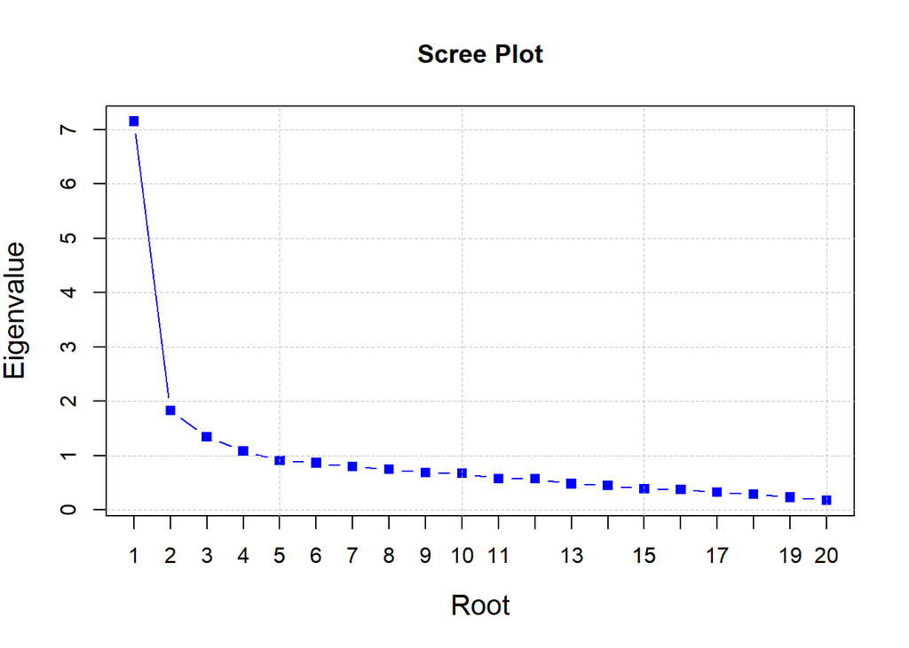

```
Scree Plot:
```

```
Specified kind of correlations for this analysis: polychoric
```

```
Total Variance Explained (Initial Eigenvalues):
```

```
             Eigenvalues    Proportion of Variance    Cumulative Prop. Variance
Factor 1            7.16                      0.36                         0.36
Factor 2            1.83                      0.09                         0.45
Factor 3            1.35                      0.07                         0.52
Factor 4            1.08                      0.05                         0.57
Factor 5            0.91                      0.05                         0.62
Factor 6            0.87                      0.04                         0.66
Factor 7            0.80                      0.04                         0.70
Factor 8            0.75                      0.04                         0.74
Factor 9            0.69                      0.03                         0.77
Factor 10           0.68                      0.03                         0.81
Factor 11           0.58                      0.03                         0.83
Factor 12           0.57                      0.03                         0.86
Factor 13           0.48                      0.02                         0.89
Factor 14           0.45                      0.02                         0.91
Factor 15           0.39                      0.02                         0.93
Factor 16           0.38                      0.02                         0.95
Factor 17           0.33                      0.02                         0.96
Factor 18           0.29                      0.01                         0.98
Factor 19           0.24                      0.01                         0.99
Factor 20           0.18                      0.01                         1.00
```

```r
SCREE_PLOT(bhsdat, corkind = 'polychoric')
```

```
A warning occurred when using method=="Revelle". method was therefore changed to "Fox"
```

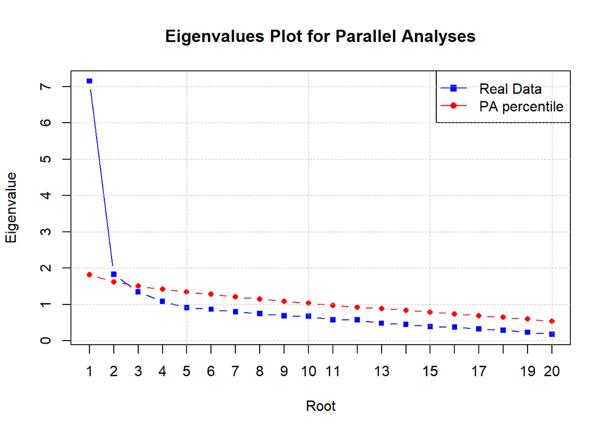

```
PARALLEL ANALYSIS
```

```
Randomization method: generated data
```

```
Type of correlations specified for the real data eigenvalues: polychoric
```

```
Type of correlations specified for the random data eigenvalues: pearson
```

```
Extraction Method: Principal Components
```

```
Variables = 20
```

```
Cases = 170
```

```
Ndatasets = 100
```

```
Percentile = 95
```

```
Compare the Real Data eigenvalues below to the corresponding
```

```
random data Mean and Percentile eigenvalues
```

```
   Root   Real_Data    Mean   Percentile
      1       7.155   1.669        1.819
      2       1.832   1.536        1.621
      3       1.349   1.441        1.511
      4       1.085   1.366        1.415
      5       0.909   1.292        1.346
      6       0.866   1.225        1.279
      7       0.799   1.161        1.208
      8       0.749   1.107        1.153
      9       0.691   1.044        1.087
     10       0.676   0.991        1.034
     11       0.578   0.937        0.975
     12       0.573   0.883        0.921
     13       0.484   0.841        0.885
     14       0.452   0.790        0.842
     15       0.393   0.742        0.791
     16       0.377   0.697        0.742
     17       0.328   0.650        0.693
     18       0.293   0.600        0.645
     19       0.236   0.546        0.597
     20       0.176   0.482        0.534
```

```
The number of factors according to the parallel analysis = 2
```

```r
RAWPAR(bhsdat, corkind = 'polychoric')
```

```r
#As reported in the text, the parallel analysis indicates that two factors underlie the BHS items.
```

### Model estimation

Next, we can fit the two-factor model to the polychoric correlation matrix using by specifying the `cor='poly'` option in the `fa()` function:

```r
bhs2f <- fa(bhsdat, nfactors=2, gam=.5, cor='poly', smooth = FALSE)
```

```
In smc, smcs < 0 were set to .0
In smc, smcs < 0 were set to .0
In smc, smcs < 0 were set to .0
```

```r
print(bhs2f)
```

```
Factor Analysis using method =  minres
Call: fa(r = bhsdat, nfactors = 2, cor = "poly", smooth = FALSE, gam = 0.5)
Standardized loadings (pattern matrix) based upon correlation matrix
      MR1   MR2   h2   u2 com
V1   0.73 -0.02 0.52 0.48 1.0
V2  -0.06  0.73 0.49 0.51 1.0
V3   0.80  0.09 0.74 0.26 1.0
V4   0.31  0.68 0.79 0.21 1.4
V5   0.69  0.33 0.83 0.17 1.4
V6   0.48  0.53 0.78 0.22 2.0
V7   0.51  0.43 0.68 0.32 1.9
V8  -0.31  0.95 0.69 0.31 1.2
V9   0.48  0.53 0.79 0.21 2.0
V10  0.43  0.46 0.60 0.40 2.0
V11  0.04  0.84 0.74 0.26 1.0
V12  0.87  0.01 0.76 0.24 1.0
V13  0.84 -0.50 0.51 0.49 1.6
V14  0.69 -0.03 0.45 0.55 1.0
V15  0.86 -0.02 0.71 0.29 1.0
V16  0.33  0.45 0.47 0.53 1.8
V17  0.35  0.31 0.33 0.67 2.0
V18  0.74 -0.14 0.46 0.54 1.1
V19  0.85  0.05 0.76 0.24 1.0
V20  0.77  0.11 0.70 0.30 1.0

                       MR1  MR2
SS loadings           8.01 4.78
Proportion Var        0.40 0.24
Cumulative Var        0.40 0.64
Proportion Explained  0.63 0.37
Cumulative Proportion 0.63 1.00

 With factor correlations of
     MR1  MR2
MR1 1.00 0.53
MR2 0.53 1.00

Mean item complexity =  1.4
Test of the hypothesis that 2 factors are sufficient.

df null model =  190  with the objective function =  146.64 with Chi Square =  23682.14
df of  the model are 151  and the objective function was  130.34

The root mean square of the residuals (RMSR) is  0.09
The df corrected root mean square of the residuals is  0.1

The harmonic n.obs is  170 with the empirical chi square  241.65  with prob <  3.9e-06
The total n.obs was  170  with Likelihood Chi Square =  20875.86  with prob <  0

Tucker Lewis Index of factoring reliability =  -0.119
RMSEA index =  0.899  and the 90 % confidence intervals are  0.891 0.912
BIC =  20100.35
Fit based upon off diagonal values = 0.97
Measures of factor score adequacy
                                                   MR1  MR2
Correlation of (regression) scores with factors   0.98 1.00
Multiple R square of scores with factors          0.96 1.00
Minimum correlation of possible factor scores     0.92 0.99
```